# Workflow-Documentation-Bike-Share

Evan Timko

2025-03-26

## Back Story

A Bike-Share company in Chicago is hiring me as a junior data analyst. My team will dive into differences between casual users and annual members use. From these insights we have to leverage the data to convert casual users to members. Let’s go!

## Objective

Find out how members and casual consumers use the cyclistic bikes differently? And how could we convince casual riders to purchase a membership?

## Setting up Enviroment

Start by installing the required packages. If you have already installed then load `tidyverse`, `skimr`,`ggplot2`,`scales1`, `readxl`, `lubridate`, `dplyr` and `janitor` in this session, feel free to skip the code chunks in this step

example of installing: install.packages(“name_of_package”)

then load it in with: library(name_of_package)

## Collecting Data

- 202401-divvy-tripdata.csv
- 202402-divvy-tripdata.csv
- 202403-divvy-tripdata.csv
- 202404-divvy-tripdata.csv
- …
- 202412-divvy-tripdata.csv

Link to data source: https://divvy-tripdata.s3.amazonaws.com/index.html

## Cleaning Data

removing any empty, null, or duplicates

```r
## removing any empty value or nulls
df19_clean <- df19[complete.cases(df19), ]


## cleaning up column names
df19_clean <- clean_names(df19_clean)


## removing duplicates rows
df19_clean <- distinct(df19_clean)
```

## Look at data for df19_clean

See if any columns are not needed right now? see if you should break down any columns into more? Are there any differences between the mass of data if using multiples data files?

```r
# add a day and month column
df19_clean$month_name <- format(df19_clean$started_at, "%B")
df19_clean$month <- month(df19_clean$started_at) ## this is so we can easily organize the data



#the week day names
df19_clean$week_day <- format(df19_clean$started_at, "%A")
df19_clean$day <- day(df19_clean$started_at)

# add time duration
df19_clean$time_duration <- df19_clean$ended_at - df19_clean$started_at
```

## Order the dataframe by month using started_at

```r
df19_clean_arranged <- df19_clean %>%
  arrange(month)
```

## graphing the total using for the year

Analysis: From the data below we can see that depending on the season it affects the user’s activity. It looks like the user only really like riding when tempeture is permitting.

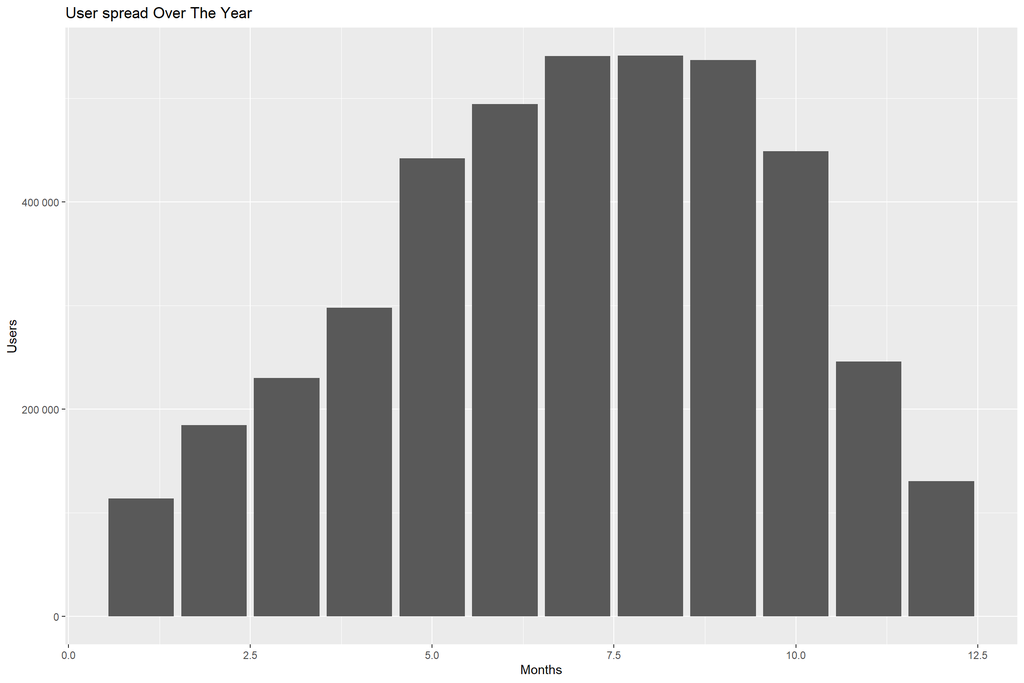

```r
## shows the amount of user in the year
ggplot(data = df19_clean) +
  geom_bar(mapping = aes(x=month)) +
  labs(title = "User spread Over The Year", x = "Months", y = "Users") +
  scale_y_continuous(labels = label_number(accuracy = 1))
```

## show the different user ride in the week

Analysis: Over the spread of the week the member’s tend to use the service more during the week. Now for the casual consumers they seem like the weekend is more popular with their demographic. This does not mean a casual consumers use it more on the weekend but rather that is best time in the week to reach a casual consumer. And the members are also using it on the weekend its just that they use it throughout the whole week, so that does not mean they are not using on the weekend like the casual customers. Maybe add a weekend only membership

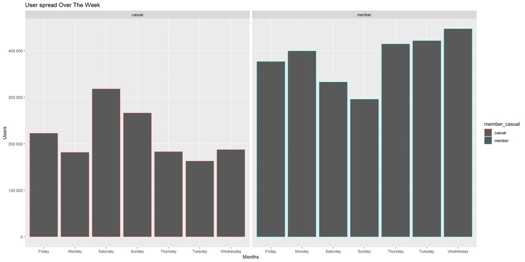

```r
ggplot(data = df19_clean) +
  geom_bar(mapping = aes(x=week_day, colour = member_casual)) +
  facet_wrap(~ member_casual) +
  labs(title = "User spread Over The Week", x = "Months", y = "Users") +
  scale_y_continuous(labels = label_number(accuracy = 1))
```

## show the different dynamic of users through the year

analysis: members clearly have a higher consistency over casual user but that jump in warmer weather should show us that we need to adjust subscription to meet the desired time need for our service.

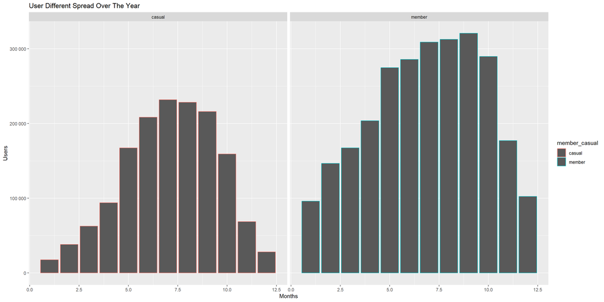

```r
# show the diferent user over the year
ggplot(data = df19_clean) +
  geom_bar(mapping = aes(x = month, color = member_casual)) +
  facet_wrap(~ member_casual) +
  labs(title = "User Different Spread Over The Year", x = "Months", y = "Users") +
  scale_y_continuous(labels = label_number(accuracy = 1))
```

## Conclusion

Based on all the data I observed I would suggest offer different pricing plans:

- One for just commuting on the weekdays
- One for just commuting on the weekends
- Students commuting
- Possible week plans
- 2/4/6 month plans to accommodate to seasonal users

By offering these different form of pricing plans it will allow casual users a higher chance of using and iteraction with our business. Which can give a higher chance of people joining as well as better reach out to the community as we offer a diverse group of pricing plans.

## Future Plans

Dive deeper into different aspects data allowing more insight. Struggled a little with graphing some data but in the future I would like to graph ideal time for renting/using bikes. Duration of time bike was used, diving deep into that as someone could be using that to travel a great distance or just a small circle many time to create a long ride.

## Conclusion

###Thank you for checking out my case study.